# Week 2: Linear Models & Least Squares

Stat 577 — Statistical Learning Theory

Soumojit Das

Spring 2026

# Linear Models: The Foundation

## Why Start with Linear Models?

Linear models are the **workhorse** of statistical learning.

**Reasons to understand them deeply:**

- Interpretable: coefficients have clear meaning
- Computationally efficient: closed-form solutions
- Theoretical foundation: many methods generalize from here
- Still competitive: often hard to beat for inference

**This week:** Understand linear regression *geometrically*, not just algebraically.

## Three Goals of Regression

What do we actually want from a linear model?

**1. Inference**

Estimate $\boldsymbol{\beta}$ and quantify uncertainty

*“Which predictors matter?”*

**2. Prediction**

Given new $\mathbf{x}$, predict $y$

*“What will happen?”*

**3. Interpretation**

Understand relationships

*“How does $X_j$ affect $Y$?”*

**Different Goals, Different Priorities**

- **Inference** prioritizes unbiasedness and valid standard errors
- **Prediction** prioritizes low test error (bias-variance tradeoff!)
- These goals can conflict—a theme we’ll revisit in Week 3

## The Linear Model

We assume:

$$Y = \beta_0 + \beta_1 X_1 + \beta_2 X_2 + \cdots + \beta_p X_p + \varepsilon$$

Or in vector notation for a single observation:

$$Y = \beta_0 + \boldsymbol{\beta}^T \mathbf{x} + \varepsilon$$

where:

- $\boldsymbol{\beta} = (\beta_1, \ldots, \beta_p)^T$ is the coefficient vector
- $\mathbf{x} = (X_1, \ldots, X_p)^T$ is the predictor vector
- $\varepsilon$ is the error with $E[\varepsilon] = 0$

# Simple Linear Regression

## One Predictor

The simplest case:

$$Y = \beta_0 + \beta_1 X + \varepsilon$$

**Goal:** Find $\hat{\beta}_0$ and $\hat{\beta}_1$ that minimize the **residual sum of squares (RSS)**:

$$\text{RSS}(\beta_0, \beta_1) = \sum_{i=1}^n (y_i - \beta_0 - \beta_1 x_i)^2$$

## Deriving the OLS Estimates

Take partial derivatives and set to zero:

$$\frac{\partial \text{RSS}}{\partial \beta_0} = -2\sum_{i=1}^n (y_i - \beta_0 - \beta_1 x_i) = 0$$

$$\frac{\partial \text{RSS}}{\partial \beta_1} = -2\sum_{i=1}^n x_i(y_i - \beta_0 - \beta_1 x_i) = 0$$

From the first equation:
$$\hat{\beta}_0 = \bar{y} - \hat{\beta}_1 \bar{x}$$

## The Closed-Form Solution

**Simple Linear Regression Estimates**

$$\hat{\beta}_1 = \frac{\sum_{i=1}^n (x_i - \bar{x})(y_i - \bar{y})}{\sum_{i=1}^n (x_i - \bar{x})^2} = \frac{S_{xy}}{S_{xx}}$$

$$\hat{\beta}_0 = \bar{y} - \hat{\beta}_1 \bar{x}$$

**Interpretation**

- $\hat{\beta}_1$ is the estimated change in $Y$ per unit change in $X$
- The regression line passes through $(\bar{x}, \bar{y})$

## Simple Linear Regression Example

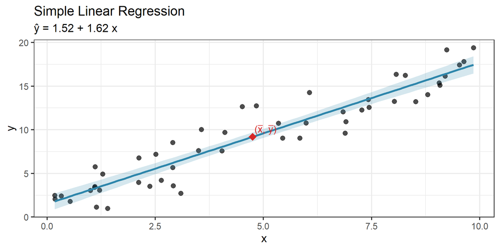

# Multiple Regression: Matrix Formulation

## The Design Matrix

With $n$ observations and $p$ predictors, write as:

$$\mathbf{y} = \mathbf{X}\boldsymbol{\beta} + \boldsymbol{\varepsilon}$$

where:

- $\mathbf{y} \in \mathbb{R}^n$ is the response vector
- $\mathbf{X} \in \mathbb{R}^{n \times (p+1)}$ is the **design matrix** (including column of 1s)
- $\boldsymbol{\beta} \in \mathbb{R}^{p+1}$ is the coefficient vector
- $\boldsymbol{\varepsilon} \in \mathbb{R}^n$ is the error vector

## The Design Matrix Structure

$$\mathbf{X} = \begin{pmatrix}
1 & x_{11} & x_{12} & \cdots & x_{1p} \\
1 & x_{21} & x_{22} & \cdots & x_{2p} \\
\vdots & \vdots & \vdots & \ddots & \vdots \\
1 & x_{n1} & x_{n2} & \cdots & x_{np}
\end{pmatrix}$$

The first column of 1s accounts for the intercept $\beta_0$.

Row $i$ of $\mathbf{X}$ contains the predictors for observation $i$.

## The Normal Equations

Minimize RSS:

$$\text{RSS}(\boldsymbol{\beta}) = (\mathbf{y} - \mathbf{X}\boldsymbol{\beta})^T(\mathbf{y} - \mathbf{X}\boldsymbol{\beta})$$

Take the gradient:

$$\nabla_{\boldsymbol{\beta}} \text{RSS} = -2\mathbf{X}^T(\mathbf{y} - \mathbf{X}\boldsymbol{\beta})$$

Setting to zero gives the **normal equations**:

$$\mathbf{X}^T\mathbf{X}\hat{\boldsymbol{\beta}} = \mathbf{X}^T\mathbf{y}$$

## The OLS Estimator

**Ordinary Least Squares (OLS) Estimator**

If $\mathbf{X}^T\mathbf{X}$ is invertible:

$$\hat{\boldsymbol{\beta}} = (\mathbf{X}^T\mathbf{X})^{-1}\mathbf{X}^T\mathbf{y}$$

**When is $\mathbf{X}^T\mathbf{X}$ invertible?**

- When columns of $\mathbf{X}$ are linearly independent
- Requires $n \geq p + 1$ (more observations than parameters)
- No perfect multicollinearity

**Numerical Stability in Practice**

In practice, we **never** compute $(\mathbf{X}^T\mathbf{X})^{-1}$ explicitly—this is numerically unstable!

Instead, `lm()` in R uses the **QR decomposition**: $\mathbf{X} = \mathbf{Q}\mathbf{R}$ where $\mathbf{Q}$ is orthonormal and $\mathbf{R}$ is upper triangular. Then:

$$\hat{\boldsymbol{\beta}} = \mathbf{R}^{-1}\mathbf{Q}^T\mathbf{y}$$

This avoids computing $\mathbf{X}^T\mathbf{X}$ (which squares the condition number) and solves via back-substitution. The formula $(\mathbf{X}^T\mathbf{X})^{-1}\mathbf{X}^T\mathbf{y}$ is for *theory*; QR is for *computation*.

**Historical Note: Origins of Least Squares**

The least squares method has a remarkable history:

- **Gauss (1795, published 1809):** Developed the method to predict the orbit of the asteroid Ceres from limited observations. His predictions proved accurate when Ceres was rediscovered.
- **Markov (1900):** Proved the optimality result we now call the Gauss-Markov theorem.
- **David (1988):** Popularized the “BLUE” acronym (Best Linear Unbiased Estimator) that we use today.

The fact that a method developed for celestial mechanics remains foundational 230 years later speaks to its mathematical elegance.

## Residuals and Fitted Values

**Fitted values:**
$$\hat{\mathbf{y}} = \mathbf{X}\hat{\boldsymbol{\beta}} = \mathbf{X}(\mathbf{X}^T\mathbf{X})^{-1}\mathbf{X}^T\mathbf{y}$$

**Residuals:**
$$\mathbf{e} = \mathbf{y} - \hat{\mathbf{y}}$$

**Key Property**

The residuals are orthogonal to the columns of $\mathbf{X}$:

$$\mathbf{X}^T\mathbf{e} = \mathbf{X}^T(\mathbf{y} - \mathbf{X}\hat{\boldsymbol{\beta}}) = \mathbf{0}$$

This follows directly from the normal equations!

# Geometry of Least Squares

## The Key Insight

**Geometric View**

Least squares finds the point in Col($\mathbf{X}$) closest to $\mathbf{y}$.

**This is orthogonal projection.**

- $\mathbf{y} \in \mathbb{R}^n$ is our observed response
- Col($\mathbf{X}$) is a $(p+1)$-dimensional subspace of $\mathbb{R}^n$
- $\hat{\mathbf{y}}$ is the projection of $\mathbf{y}$ onto Col($\mathbf{X}$)
- $\mathbf{e} = \mathbf{y} - \hat{\mathbf{y}}$ is perpendicular to Col($\mathbf{X}$)

## Visualizing the Projection (p = 2)

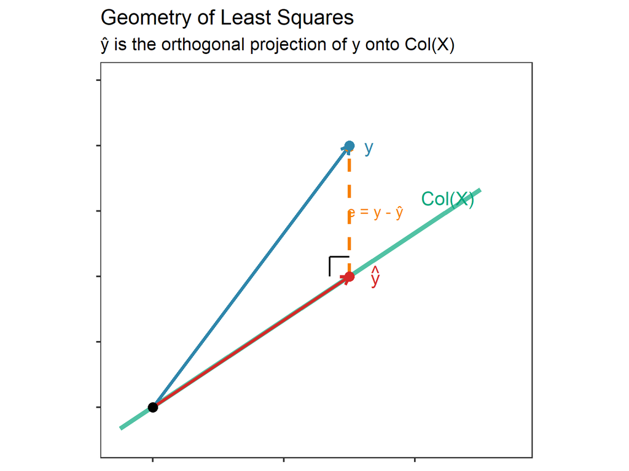

## Interactive 3D View: Explore the Projection

**Rotate this plot** to see how $\hat{\mathbf{y}}$ is the closest point in Col($\mathbf{X}$) to $\mathbf{y}$.

[interactive chart not shown]

**What to Look For**

- **Rotate** to see that $\mathbf{e}$ is truly perpendicular to the green plane
- The **right angle marker** at $\hat{\mathbf{y}}$ confirms orthogonality
- $\hat{\mathbf{y}}$ is the unique point in Col($\mathbf{X}$) closest to $\mathbf{y}$

## The Hat Matrix

**Definition: Hat Matrix**

$$\mathbf{H} = \mathbf{X}(\mathbf{X}^T\mathbf{X})^{-1}\mathbf{X}^T$$

This matrix “puts the hat on $\mathbf{y}$”:
$$\hat{\mathbf{y}} = \mathbf{H}\mathbf{y}$$

**$\mathbf{H}$ is the projection matrix onto Col($\mathbf{X}$).**

## Properties of the Hat Matrix

**Algebraic Properties:**

1. **Symmetric:** $\mathbf{H}^T = \mathbf{H}$
2. **Idempotent:** $\mathbf{H}^2 = \mathbf{H}$
3. **Eigenvalues:** All 0 or 1
4. **Trace:** $\text{tr}(\mathbf{H}) = p + 1$

**Geometric Meaning:**

- $\mathbf{H}\mathbf{y}$ = projection of $\mathbf{y}$
- $(\mathbf{I} - \mathbf{H})\mathbf{y}$ = residual
- Applying twice = once (idempotent)
- Rank = dimension of Col($\mathbf{X}$)

**Why “Hat” Matrix?**

It’s called the hat matrix because it puts the “hat” ($\hat{}$) on $\mathbf{y}$!

## Proof: $\mathbf{H}$ is Idempotent

$$\mathbf{H}^2 = \mathbf{X}(\mathbf{X}^T\mathbf{X})^{-1}\mathbf{X}^T \cdot \mathbf{X}(\mathbf{X}^T\mathbf{X})^{-1}\mathbf{X}^T$$

$$= \mathbf{X}(\mathbf{X}^T\mathbf{X})^{-1}[\mathbf{X}^T\mathbf{X}](\mathbf{X}^T\mathbf{X})^{-1}\mathbf{X}^T$$

$$= \mathbf{X}(\mathbf{X}^T\mathbf{X})^{-1}\mathbf{X}^T = \mathbf{H}$$

**Geometric Intuition**

Projecting twice onto the same subspace gives the same result as projecting once.

## Residuals Live in the Orthogonal Complement

The residual maker matrix:
$$\mathbf{M} = \mathbf{I} - \mathbf{H}$$

Properties:

- $\mathbf{M}$ is also symmetric and idempotent
- $\mathbf{M}$ projects onto the orthogonal complement of Col($\mathbf{X}$)
- $\mathbf{e} = \mathbf{M}\mathbf{y}$

**Key:** $\mathbf{H}\mathbf{M} = \mathbf{0}$ — fitted values and residuals are orthogonal!

## Leverage: Diagonal of $\mathbf{H}$

The $i$th diagonal element of $\mathbf{H}$:

$$h_{ii} = \mathbf{x}_i^T(\mathbf{X}^T\mathbf{X})^{-1}\mathbf{x}_i$$

This is the **leverage** of observation $i$.

**Interpretation of Leverage**

- $h_{ii}$ measures how much $y_i$ influences $\hat{y}_i$
- $\hat{y}_i = h_{ii} y_i + \sum_{j \neq i} h_{ij} y_j$
- High leverage = unusual $\mathbf{x}_i$ values
- When model includes intercept: $1/n \leq h_{ii} \leq 1$ and $\sum_i h_{ii} = p + 1$
- Without intercept: $0 \leq h_{ii} \leq 1$

# Gauss-Markov Theorem

## What Makes OLS Special?

**Gauss-Markov Theorem**

Among all **linear unbiased estimators** of $\boldsymbol{\beta}$, the OLS estimator has the smallest variance.

**OLS is BLUE:** Best Linear Unbiased Estimator

**Assumptions needed:**

1. $E[\boldsymbol{\varepsilon}] = \mathbf{0}$ (errors have mean zero)
2. $\text{Cov}(\boldsymbol{\varepsilon}) = \sigma^2 \mathbf{I}$ (homoskedasticity, uncorrelated errors)
3. $\mathbf{X}$ is fixed (non-random), OR if $\mathbf{X}$ is random, assumptions 1-2 hold conditionally on $\mathbf{X}$

**What About Full Rank?**

**Common simplification:** Assume $\text{rank}(\mathbf{X}) = p + 1$ so $\mathbf{X}^T\mathbf{X}$ is invertible.

**But the theorem is more general!** See next slide.

## The General Gauss-Markov Theorem

When $\mathbf{X}$ is **rank-deficient**, $\boldsymbol{\beta}$ itself isn’t uniquely identifiable. But we can still do inference!

**Estimable Functions**

A linear function $\mathbf{c}^T\boldsymbol{\beta}$ is **estimable** if $\mathbf{c}$ lies in the row space of $\mathbf{X}$.

Equivalently: $\mathbf{c}^T\boldsymbol{\beta}$ is estimable iff it has the same value for all $\boldsymbol{\beta}$ satisfying $\mathbf{X}\boldsymbol{\beta} = E[\mathbf{y}]$.

**General Gauss-Markov:** For any estimable $\mathbf{c}^T\boldsymbol{\beta}$, the OLS estimator

$$\mathbf{c}^T\hat{\boldsymbol{\beta}} = \mathbf{c}^T(\mathbf{X}^T\mathbf{X})^{-}\mathbf{X}^T\mathbf{y}$$

is BLUE, where $(\mathbf{X}^T\mathbf{X})^{-}$ is *any* generalized inverse.

**Key insight:** The choice of g-inverse doesn’t matter for estimable functions — they all give the same answer!

## Why This Matters

**Full rank (common case):**

- All functions of $\boldsymbol{\beta}$ are estimable
- $\boldsymbol{\beta}$ uniquely identified
- Use ordinary inverse $(\mathbf{X}^T\mathbf{X})^{-1}$

**Rank deficient:**

- Only estimable functions have BLUEs
- $\boldsymbol{\beta}$ not unique, but $\hat{\mathbf{y}} = \mathbf{X}\hat{\boldsymbol{\beta}}$ is!
- Use any g-inverse (Moore-Penrose, reflexive, etc.)

## Estimable Functions in Practice

**Intuition: What Makes Something Estimable?**

A function of $\boldsymbol{\beta}$ is **estimable** if you get the same answer no matter which valid $\boldsymbol{\beta}$ parameterization you use.

Think of it this way: if there are multiple $\boldsymbol{\beta}$ vectors that all produce the same fitted values $\hat{\mathbf{y}}$, then any quantity that differs across these $\boldsymbol{\beta}$’s is *not* estimable—the data cannot distinguish between them. Only quantities that are the *same* for all valid $\boldsymbol{\beta}$’s can be estimated from the data.

Often, what we *actually* care about is estimable — even when $\boldsymbol{\beta}$ isn’t identified!

**Example: One-way ANOVA with cell means coding**

$$y_{ij} = \mu_i + \varepsilon_{ij}, \quad i = 1, \ldots, k; \; j = 1, \ldots, n_i$$

| Quantity | Estimable? | Why it matters |
| --- | --- | --- |
| $\mu_1$ | ✓ Yes | Individual group mean |
| $\mu_1 - \mu_2$ | ✓ Yes | Treatment contrast |
| $\frac{1}{k}\sum_i \mu_i$ | ✓ Yes | Overall mean |
| $\hat{y}$ for any $\mathbf{x}$ in data | ✓ Yes | Predictions always work |

**Example: Regression with perfect collinearity**

If $X_3 = X_1 + X_2$ exactly, then $\beta_1, \beta_2, \beta_3$ aren’t individually identifiable.

But $\beta_1 + \beta_3$ and $\beta_2 + \beta_3$ *are* estimable — and often that’s what we need!

## What G-Inverses Do NOT Solve

**Critical Distinction**

**G-inverses handle rank deficiency from linear dependencies.**

They do **NOT** solve the $p \gg n$ problem!

**Two very different situations:**

**Rank deficiency (g-inverses help)**

- $n = 100$, $p = 10$, but 2 columns linearly dependent
- $\text{rank}(\mathbf{X}) = 9 < p$
- Problem: Some $\beta_j$’s not identified
- Solution: Focus on estimable functions
- Inference is valid for what’s estimable

**High-dimensional ($p > n$, g-inverses don’t help)**

- $n = 100$, $p = 1000$
- $\text{rank}(\mathbf{X}) \leq n < p$
- Problem: Massive overfitting, infinite solutions
- G-inverse gives *a* solution, but terrible prediction
- Need: Regularization (Week 3!)

**Why the Difference?**

With $p > n$: even with g-inverse, $\hat{\mathbf{y}} = \mathbf{X}\hat{\boldsymbol{\beta}}$ interpolates the training data perfectly.

**Zero training error, catastrophic test error.** This is the overfitting problem — no amount of linear algebra solves it. We need to *constrain* the solution space.

## Proof Sketch: Setting Up

Consider any other linear estimator:
$$\tilde{\boldsymbol{\beta}} = \mathbf{C}\mathbf{y}$$

for some matrix $\mathbf{C} \in \mathbb{R}^{(p+1) \times n}$.

For unbiasedness:
$$E[\tilde{\boldsymbol{\beta}}] = \mathbf{C}E[\mathbf{y}] = \mathbf{C}\mathbf{X}\boldsymbol{\beta} = \boldsymbol{\beta}$$

This requires $\mathbf{C}\mathbf{X} = \mathbf{I}$.

## Proof Sketch: Comparing Variances

Write $\mathbf{C} = (\mathbf{X}^T\mathbf{X})^{-1}\mathbf{X}^T + \mathbf{D}$ for some matrix $\mathbf{D}$.

The unbiasedness condition $\mathbf{C}\mathbf{X} = \mathbf{I}$ implies:
$$\mathbf{D}\mathbf{X} = \mathbf{0}$$

Variance of $\tilde{\boldsymbol{\beta}}$:
$$\text{Var}(\tilde{\boldsymbol{\beta}}) = \sigma^2 \mathbf{C}\mathbf{C}^T$$

## Proof Sketch: The Key Step

$$\mathbf{C}\mathbf{C}^T = [(\mathbf{X}^T\mathbf{X})^{-1}\mathbf{X}^T + \mathbf{D}][(\mathbf{X}^T\mathbf{X})^{-1}\mathbf{X}^T + \mathbf{D}]^T$$

$$= (\mathbf{X}^T\mathbf{X})^{-1} + \mathbf{D}\mathbf{D}^T + \underbrace{(\mathbf{X}^T\mathbf{X})^{-1}\mathbf{X}^T\mathbf{D}^T}_{= 0} + \underbrace{\mathbf{D}\mathbf{X}(\mathbf{X}^T\mathbf{X})^{-1}}_{= 0}$$

Since $\mathbf{D}\mathbf{X} = \mathbf{0}$:
$$\text{Var}(\tilde{\boldsymbol{\beta}}) = \sigma^2[(\mathbf{X}^T\mathbf{X})^{-1} + \mathbf{D}\mathbf{D}^T]$$

Since $\mathbf{D}\mathbf{D}^T$ is positive semi-definite, $\text{Var}(\tilde{\boldsymbol{\beta}}) \geq \text{Var}(\hat{\boldsymbol{\beta}})$.

## What Gauss-Markov Does NOT Say

**Limitations**

1. **Only compares linear estimators** — nonlinear estimators might be better
2. **Only considers unbiased estimators** — biased estimators might have lower MSE
3. **Doesn’t guarantee small variance** — just smallest among linear unbiased
4. **Assumes homoskedasticity** — if violated, OLS is not BLUE

**This motivates regularization!** (Ridge, Lasso in Week 3)

**Preview: Ridge Regression**

Ridge regression adds a penalty to the OLS objective, yielding:

$$\hat{\boldsymbol{\beta}}_{\text{ridge}} = (\mathbf{X}^T\mathbf{X} + \lambda\mathbf{I})^{-1}\mathbf{X}^T\mathbf{y}$$

where $\lambda \geq 0$ is a tuning parameter.

**Key insight:** Compare to OLS: $\hat{\boldsymbol{\beta}} = (\mathbf{X}^T\mathbf{X})^{-1}\mathbf{X}^T\mathbf{y}$

- When $\lambda = 0$: Ridge = OLS (unbiased, potentially high variance)
- As $\lambda \to \infty$: $\hat{\boldsymbol{\beta}}_{\text{ridge}} \to \mathbf{0}$ (high bias, low variance)

The parameter $\lambda$ gives us **explicit control** over the bias-variance tradeoff. We’ll develop this fully in Week 3.

## Connecting to Bias-Variance

**Recall from Week 1**

$$\text{EPE}(\hat{f}) = \underbrace{\sigma^2}_{\text{irreducible}} + \underbrace{[\text{Bias}(\hat{f})]^2}_{\text{model wrong?}} + \underbrace{\text{Var}(\hat{f})}_{\text{estimation noise}}$$

**For OLS under the correct linear model:**

- Bias = 0 (OLS is unbiased)
- Gauss-Markov says: variance is minimized among linear unbiased estimators

**But what if we’re willing to accept some bias?**

- A biased estimator with *much lower* variance might have lower total MSE
- This is exactly the tradeoff Ridge and Lasso exploit
- James & Stein (1961): For $p \geq 3$, OLS is *inadmissible*—there exist estimators that dominate it in total squared error!

## Bias-Variance at a Test Point

For a new observation $\mathbf{x}_0$, the OLS prediction is $\hat{y}_0 = \mathbf{x}_0^T \hat{\boldsymbol{\beta}}$.

**Prediction Variance**

$$\text{Var}(\hat{y}_0) = \sigma^2 \mathbf{x}_0^T (\mathbf{X}^T\mathbf{X})^{-1} \mathbf{x}_0$$

**Under correct model specification:**

- **Bias:** $E[\hat{y}_0] - E[y_0] = 0$ (OLS is unbiased)
- **Variance:** Depends on $\mathbf{x}_0$ and the design matrix geometry
- **MSE:** $\text{MSE}(\hat{y}_0) = \sigma^2 \mathbf{x}_0^T (\mathbf{X}^T\mathbf{X})^{-1} \mathbf{x}_0$

**Connection to Week 1**

Recall the bias-variance decomposition: $\text{EPE} = \sigma^2 + \text{Bias}^2 + \text{Variance}$.

For OLS under correct specification, Bias = 0, so prediction error is driven entirely by variance and irreducible noise. Regularization (Week 3) trades bias for reduced variance.

# Distributional Properties

## Under Normality Assumptions

Add a stronger assumption:

$$\boldsymbol{\varepsilon} \sim N(\mathbf{0}, \sigma^2\mathbf{I})$$

Then we get exact finite-sample distributions:

**Distribution of $\hat{\boldsymbol{\beta}}$**

$$\hat{\boldsymbol{\beta}} \sim N(\boldsymbol{\beta}, \sigma^2(\mathbf{X}^T\mathbf{X})^{-1})$$

The covariance matrix $\sigma^2(\mathbf{X}^T\mathbf{X})^{-1}$ tells us about precision of each estimate.

## Estimating $\sigma^2$

We don’t know $\sigma^2$, so we estimate it:

$$\hat{\sigma}^2 = \frac{\text{RSS}}{n - p - 1} = \frac{\mathbf{e}^T\mathbf{e}}{n - p - 1} = \frac{\sum_{i=1}^n e_i^2}{n - p - 1}$$

**Degrees of Freedom**

Why $n - p - 1$?

$$E[\mathbf{e}^T\mathbf{e}] = E[\mathbf{y}^T(\mathbf{I} - \mathbf{H})\mathbf{y}] = \sigma^2 \text{tr}(\mathbf{I} - \mathbf{H}) = \sigma^2(n - p - 1)$$

We “use up” $p + 1$ degrees of freedom estimating $\boldsymbol{\beta}$.

**Intuition: Why Residuals Have Fewer Degrees of Freedom**

The residuals $\mathbf{e}$ are not free to vary in all $n$ dimensions—they are **constrained** by the normal equations $\mathbf{X}^T\mathbf{e} = \mathbf{0}$.

This gives $p + 1$ linear constraints (one for each column of $\mathbf{X}$, including the intercept). So while we have $n$ residuals, they only have $n - (p+1)$ degrees of freedom to move around.

Equivalently: the residuals live in the $(n - p - 1)$-dimensional orthogonal complement of Col($\mathbf{X}$).

## Independence of $\hat{\boldsymbol{\beta}}$ and $\hat{\sigma}^2$

**Key Result**

Under normality, $\hat{\boldsymbol{\beta}}$ and $\hat{\sigma}^2$ are **independent**.

Furthermore:

$$\frac{(n - p - 1)\hat{\sigma}^2}{\sigma^2} \sim \chi^2_{n-p-1}$$

These results enable exact inference (t-tests, F-tests).

## Standard Errors

The estimated standard error of $\hat{\beta}_j$:

$$\text{SE}(\hat{\beta}_j) = \hat{\sigma}\sqrt{[(\mathbf{X}^T\mathbf{X})^{-1}]_{jj}}$$

This measures our uncertainty about $\hat{\beta}_j$.

## When Homoskedasticity Fails: Robust Standard Errors

What if $\text{Var}(\varepsilon_i) = \sigma_i^2$ varies across observations?

**Under Heteroskedasticity**

- OLS $\hat{\boldsymbol{\beta}}$ is still unbiased and consistent
- But the usual standard errors are **wrong** (often too small)
- t-tests and confidence intervals become unreliable

**Heteroskedasticity-Robust (Sandwich) Standard Errors**

**White (1980)** proposed the “sandwich” estimator:

$$\widehat{\text{Var}}(\hat{\boldsymbol{\beta}})_{\text{robust}} = (\mathbf{X}^T\mathbf{X})^{-1}\left(\sum_{i=1}^n e_i^2 \mathbf{x}_i\mathbf{x}_i^T\right)(\mathbf{X}^T\mathbf{X})^{-1}$$

where $e_i = y_i - \mathbf{x}_i^T\hat{\boldsymbol{\beta}}$ are the residuals.

**In R:** Use `sandwich::vcovHC()` with `lmtest::coeftest()`:

```r
library(sandwich); library(lmtest)
fit <- lm(y ~ x1 + x2, data = mydata)
coeftest(fit, vcov = vcovHC(fit, type = "HC3"))
```

The “HC3” variant is recommended for small samples (MacKinnon & White, 1985).

**Beyond Independence: Generalized Least Squares**

When errors are **correlated** (e.g., time series, spatial data, clustered observations):

$$\text{Cov}(\boldsymbol{\varepsilon}) = \sigma^2 \boldsymbol{\Omega} \neq \sigma^2 \mathbf{I}$$

The **Generalized Least Squares (GLS)** estimator accounts for this structure:

$$\hat{\boldsymbol{\beta}}_{\text{GLS}} = (\mathbf{X}^T\boldsymbol{\Omega}^{-1}\mathbf{X})^{-1}\mathbf{X}^T\boldsymbol{\Omega}^{-1}\mathbf{y}$$

**Key properties:** GLS is BLUE when $\boldsymbol{\Omega}$ is known. In practice, $\boldsymbol{\Omega}$ must be estimated (Feasible GLS). Common applications include time series (AR errors), panel data, and spatial models.

**In R:** `nlme::gls()` or specify correlation structures in mixed models.

# Inference

## Testing Individual Coefficients

To test $H_0: \beta_j = 0$:

$$t_j = \frac{\hat{\beta}_j}{\text{SE}(\hat{\beta}_j)} \sim t_{n-p-1} \text{ under } H_0$$

**Interpretation:** Is predictor $j$ useful after accounting for all other predictors?

**Caution: Multicollinearity Trap**

A non-significant $t$-test doesn’t mean the predictor is unimportant—it could be collinear with others.

- Individual $t$-tests: $p = 0.12$ for $X_1$, $p = 0.15$ for $X_2$ (both non-significant)
- Joint $F$-test for $H_0: \beta_1 = \beta_2 = 0$: $p < 0.001$ (highly significant!)

**Why?** Each predictor’s $t$-test asks “does this help *given the other*?” With correlated predictors, neither adds much unique information beyond the other—but together they explain substantial variance.

**Rule:** Always examine joint $F$-tests alongside individual $t$-tests when predictors are correlated.

## Confidence Intervals

A $(1-\alpha)$ confidence interval for $\beta_j$:

$$\hat{\beta}_j \pm t_{n-p-1, \alpha/2} \cdot \text{SE}(\hat{\beta}_j)$$

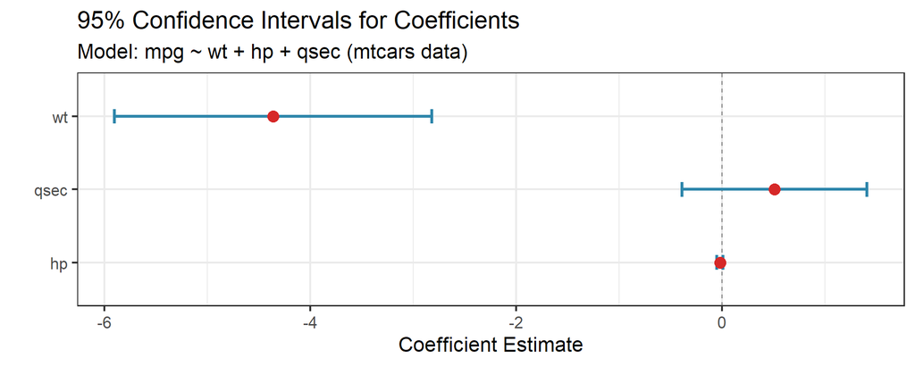

## F-Test for Nested Models

To compare a reduced model to a full model:

$$F = \frac{(\text{RSS}_{\text{reduced}} - \text{RSS}_{\text{full}}) / q}{\text{RSS}_{\text{full}} / (n - p - 1)} \sim F_{q, n-p-1}$$

where $q$ is the number of additional parameters in the full model.

**Use case:** Testing whether a group of predictors improves the model.

## Overall F-Test

Testing $H_0: \beta_1 = \beta_2 = \cdots = \beta_p = 0$ (all coefficients zero):

$$F = \frac{(\text{TSS} - \text{RSS})/p}{\text{RSS}/(n - p - 1)} = \frac{R^2 / p}{(1 - R^2)/(n - p - 1)}$$

where $R^2 = 1 - \text{RSS}/\text{TSS}$ is the coefficient of determination.

## $R^2$ and Adjusted $R^2$

**$R^2$:** Proportion of variance explained
$$R^2 = 1 - \frac{\text{RSS}}{\text{TSS}} = 1 - \frac{\sum_i(y_i - \hat{y}_i)^2}{\sum_i(y_i - \bar{y})^2}$$

**Problem:** $R^2$ always increases when adding predictors.

**Adjusted $R^2$:** Penalizes for number of predictors
$$R^2_{\text{adj}} = 1 - \frac{\text{RSS}/(n - p - 1)}{\text{TSS}/(n - 1)}$$

# Model Diagnostics

## Why Diagnostics Matter

OLS assumes:

1. Linear relationship
2. Constant variance (homoskedasticity)
3. Independence of errors
4. Normal errors (for inference)
5. No extreme outliers

**Diagnostics help us check these assumptions.**

## Residual Plots

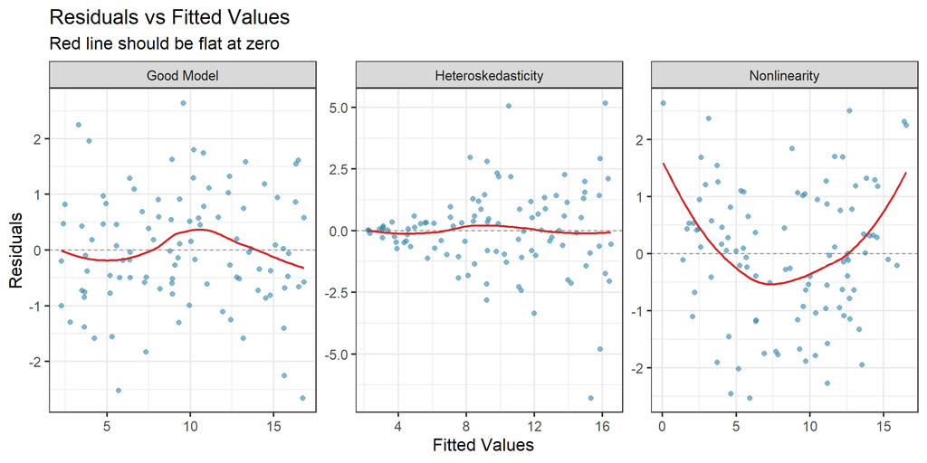

## Q-Q Plot: Checking Normality

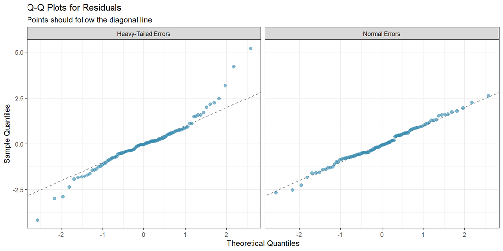

## Leverage and Influence

[figure not shown]

## Diagnostic Summary

| Issue | Detection | Consequence | Remedy |
| --- | --- | --- | --- |
| Nonlinearity | Residual plots | Biased estimates | Transform predictors; add polynomial terms; use nonlinear model |
| Heteroskedasticity | Residual vs fitted | Invalid inference | Weighted LS; robust SEs; transform response |
| Non-normality | Q-Q plot | Invalid inference | Bootstrap; transform response; robust methods |
| High leverage | Hat values $h_{ii}$ | Sensitive to outliers | Investigate data entry; consider robust regression |
| Influential points | Cook’s distance | Model driven by few points | Sensitivity analysis; robust regression; report with/without |
| Multicollinearity | VIF | Large standard errors | Remove/combine predictors; ridge regression; collect more data |

## Code Demo: Full Diagnostic Check

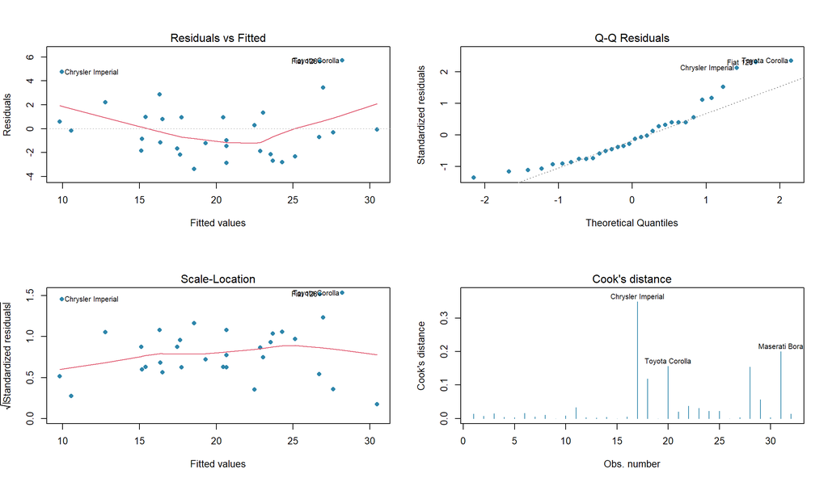

# Summary

## What We Covered

1. **Linear model setup:** $\mathbf{y} = \mathbf{X}\boldsymbol{\beta} + \boldsymbol{\varepsilon}$
2. **OLS estimator:** $\hat{\boldsymbol{\beta}} = (\mathbf{X}^T\mathbf{X})^{-1}\mathbf{X}^T\mathbf{y}$
3. **Geometry:** Least squares = orthogonal projection onto Col($\mathbf{X}$)
4. **Hat matrix:** $\mathbf{H} = \mathbf{X}(\mathbf{X}^T\mathbf{X})^{-1}\mathbf{X}^T$ projects $\mathbf{y}$ to $\hat{\mathbf{y}}$
5. **Gauss-Markov:** OLS is BLUE (among linear unbiased estimators)
6. **Inference:** t-tests, F-tests, confidence intervals under normality
7. **Diagnostics:** Residual plots, Q-Q plots, leverage, influence

## Key Insights

**Remember These**

- **Geometry over algebra:** Thinking about projections gives deeper understanding
- **Gauss-Markov limits:** Only optimal among linear unbiased — biased estimators may be better!
- **Diagnostics matter:** Conclusions depend on assumptions being (approximately) satisfied

## Looking Ahead

**We built the foundation this week.** Now we break some rules.

**What we established:**

- OLS has beautiful geometry
- Gauss-Markov: BLUE among linear unbiased
- Clear inference under normality

**What we hinted at:**

- Unbiasedness isn’t everything
- Stein’s paradox: OLS is inadmissible for $p \geq 3$
- Bias-variance tradeoff applies here too

**Next week:** Ridge, Lasso, Elastic Net — *deliberately biased* estimators that often outperform OLS.